# Project 2 Question 2

Luke Sturgeon  
Stat 517  
Due Date: 10/29/18

### Load Packages and Data

```r
Mt<-read.csv("http://www.webpages.uidaho.edu/~stevel/Datasets/Mt1t.mutate.csv",header=TRUE,sep=',')
Mt<-Mt[-c(1:3),]
install.packages("mclust",repos="https://cloud.r-project.org")
install.packages("dplyr",repos="https://cloud.r-project.org")
install.packages("cluster",repos="https://cloud.r-project.org")
install.packages("ggplot2",repos="https://cloud.r-project.org")
install.packages("plotly", repos="https://cloud.r-project.org")
install.packages("factoextra", repos="https://cloud.r-project.org")
install.packages("arules",repos="https://cloud.r-project.org")
install.packages("arulesViz",repos="https://cloud.r-project.org")
library(arulesViz)
library(arules)
library(factoextra)
library(mclust)
library(cluster)
library(dplyr)
library(ggplot2)
library(plotly)
dim(Mt)
```

```
## [1] 1074 2712
```

### Pre-processing and PCA

This problem is concerned with finding how the data groups itself. We would like to see if the data is organized as the given haplogroups say, or if we find another distribution of haplogroups when we analyze the data. We start first with PCA to reduce the size of the dataset into something more manageable, then find the optimal number of components through various methods.

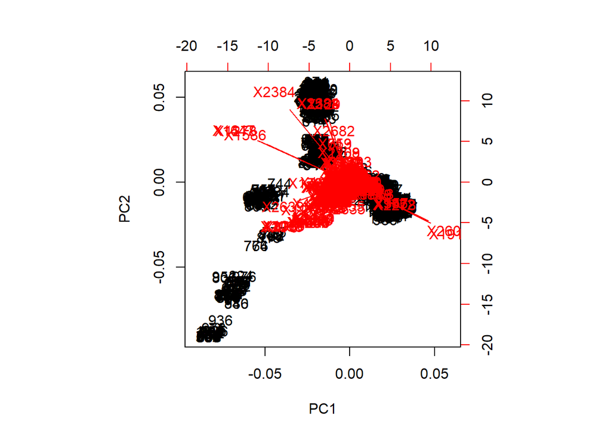

```r
print(get_eig(MtPCA)[550:560,])
```

```
##          eigenvalue variance.percent cumulative.variance.percent
## Dim.550 0.002391653       0.01175647                    97.94129
## Dim.551 0.002382156       0.01170979                    97.95300
## Dim.552 0.002374395       0.01167164                    97.96467
## Dim.553 0.002363689       0.01161901                    97.97629
## Dim.554 0.002359482       0.01159833                    97.98789
## Dim.555 0.002354177       0.01157225                    97.99946
## Dim.556 0.002343925       0.01152186                    98.01098
## Dim.557 0.002332093       0.01146369                    98.02245
## Dim.558 0.002325672       0.01143213                    98.03388
## Dim.559 0.002314024       0.01137488                    98.04525
## Dim.560 0.002301875       0.01131516                    98.05657
```

```r
get_eig(MtPCA)[210:220,]
```

```
##          eigenvalue variance.percent cumulative.variance.percent
## Dim.210 0.009804085       0.04819322                    89.61182
## Dim.211 0.009775933       0.04805483                    89.65988
## Dim.212 0.009710639       0.04773387                    89.70761
## Dim.213 0.009624677       0.04731132                    89.75492
## Dim.214 0.009615614       0.04726676                    89.80219
## Dim.215 0.009581054       0.04709688                    89.84928
## Dim.216 0.009472563       0.04656358                    89.89585
## Dim.217 0.009453063       0.04646772                    89.94232
## Dim.218 0.009420468       0.04630750                    89.98862
## Dim.219 0.009390937       0.04616233                    90.03479
## Dim.220 0.009317298       0.04580035                    90.08059
```

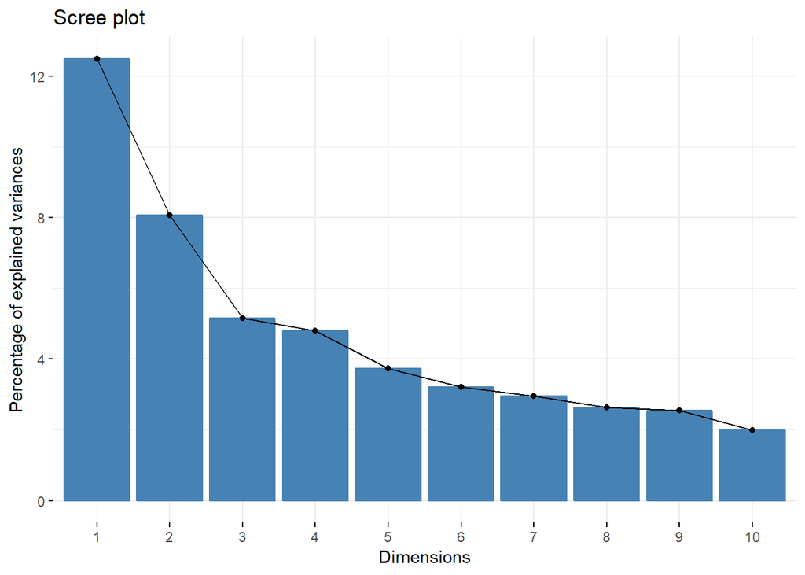

```r
fviz_eig(MtPCA)
```

We see that 556 dimensions will give us 98% of the variance explained, significantly reducing the amount of data we have to compute and only losing 2% of our explanatory variance. Unfortunately, reducing the size of the dataset by nearly half isn’t enough to give us reasonable computation speeds. I’ve had to reduce the number of dimensions to 218 so that 90% of the original variation is captured.

```r
pca.frame <- MtPCA$x[,1:218]
```

Now we can start with our clustering and see how closely the clusters we find match with the haplogroups given to us.

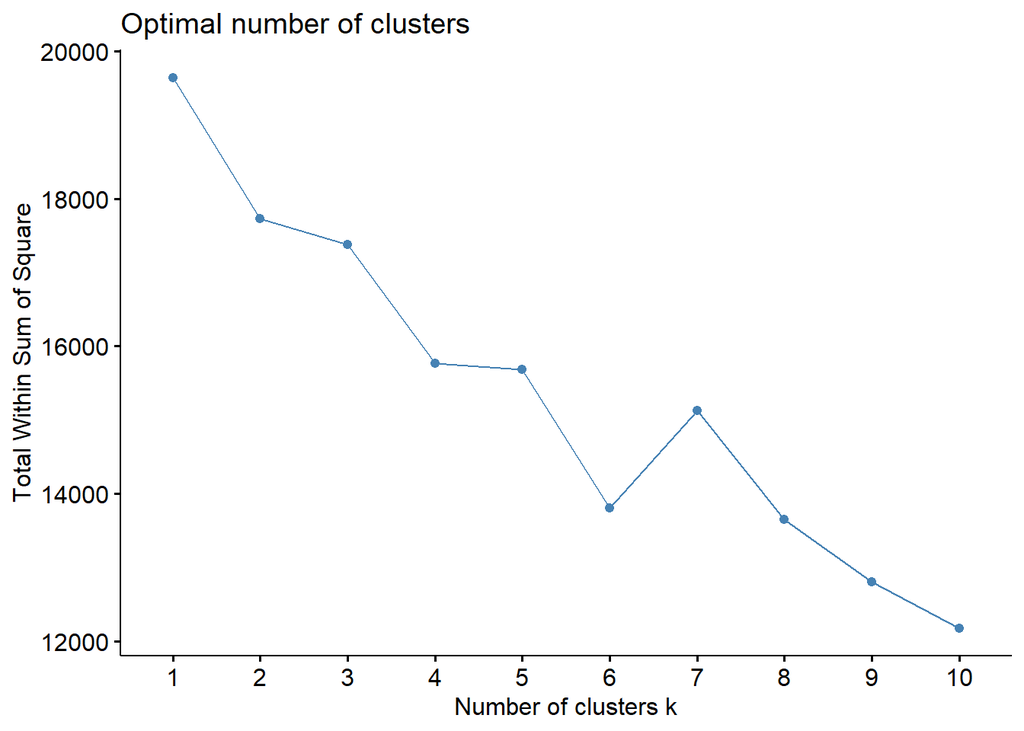

```r
fviz_nbclust(pca.frame,kmeans,method="wss")
```

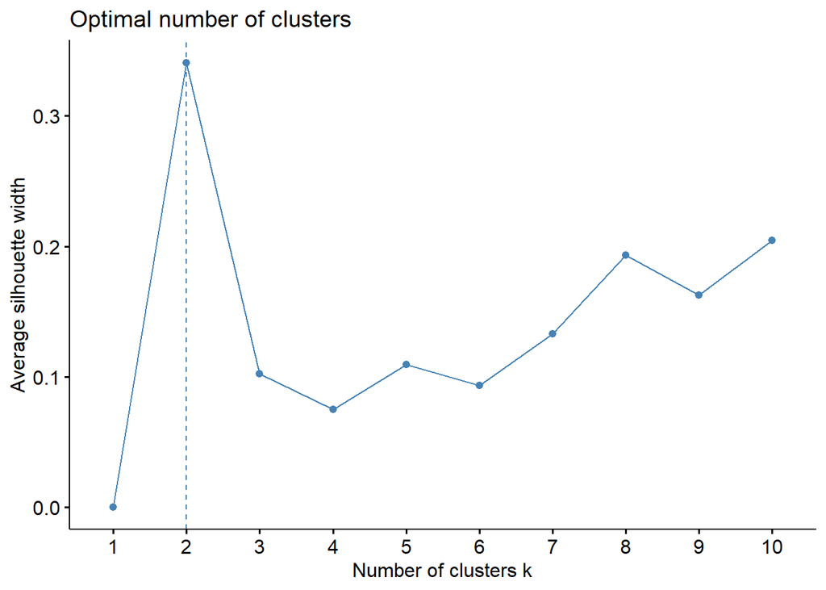

```r
fviz_nbclust(pca.frame,kmeans,method="silhouette")
```

```r
mclust <- Mclust(pca.frame)
summary(mclust)
```

```
## ----------------------------------------------------
## Gaussian finite mixture model fitted by EM algorithm
## ----------------------------------------------------
##
## Mclust VVI (diagonal, varying volume and shape) model with 3 components:
##
##  log.likelihood    n   df      BIC      ICL
##        116478.7 1074 1310 223814.7 223812.9
##
## Clustering table:
##   1   2   3
## 478 586  10
```

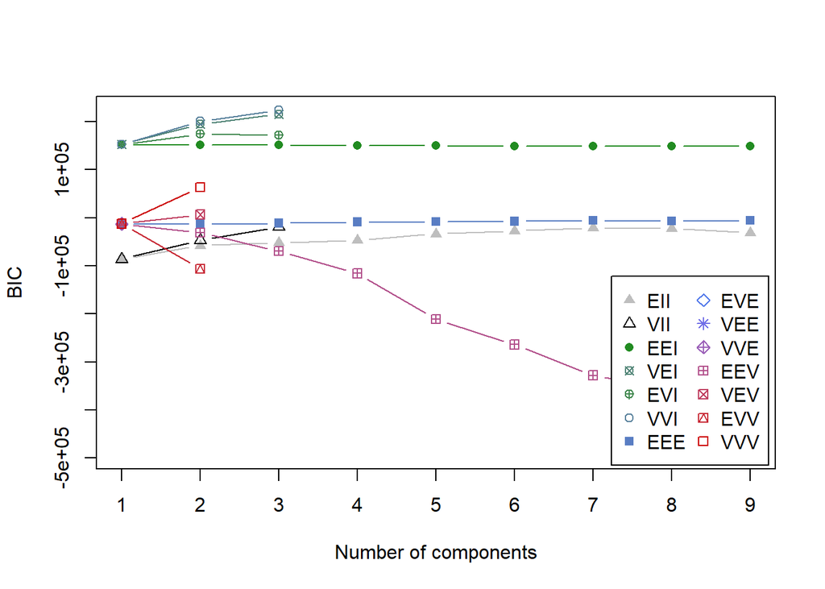

```r
plot(mclust$BIC)
```

```r
table(Mt$Group,mclust$classification)
```

```
##
##                   1   2   3
##   A              49  38   0
##   B              31  56   0
##   C              18  15   0
##   CNSS            0   0   0
##   D              34  54   0
##   F               1  28   0
##   G               0  20   0
##   H             129  48   0
##   I               0   6   0
##   J              18  17   0
##   K               4  20   0
##   L0              8  15   0
##   L1              0  12   0
##   L1b            25   2   0
##   L2             22  41   0
##   L3             22  13  10
##   L3e            15  36   0
##   L3h             0   6   0
##   L5              0   9   0
##   Lx              2   5   0
##   Ly              0   1   0
##   M              18  34   0
##   N              16   8   0
##   O               0   6   0
##   Position_site   0   0   0
##   Q               0   4   0
##   R               5   1   0
##   RSRS            0   0   0
##   S               0   1   0
##   T              21  15   0
##   U              34  49   0
##   V               6   7   0
##   W               0  12   0
##   X               0   7   0
```

```r
adjustedRandIndex(Mt$Group,mclust$classification)
```

```
## [1] 0.0188398
```

Model based clustering is not doing a very good job. It’s having a hard time separating the data into more than three distinct groups, so our accuracy is terrible. I have higher hopes for k-means, mostly because I can adjust how many centers to drop into the model.

```r
k3 <- kmeans(pca.frame,3)
k10 <- kmeans(pca.frame,10) # This is the amount suggest by the "wss" method of NbClust
print(str(Mt$Group))
```

```
##  Factor w/ 34 levels "A","B","C","CNSS",..: 8 30 8 34 10 8 10 31 10 34 ...
## NULL
```

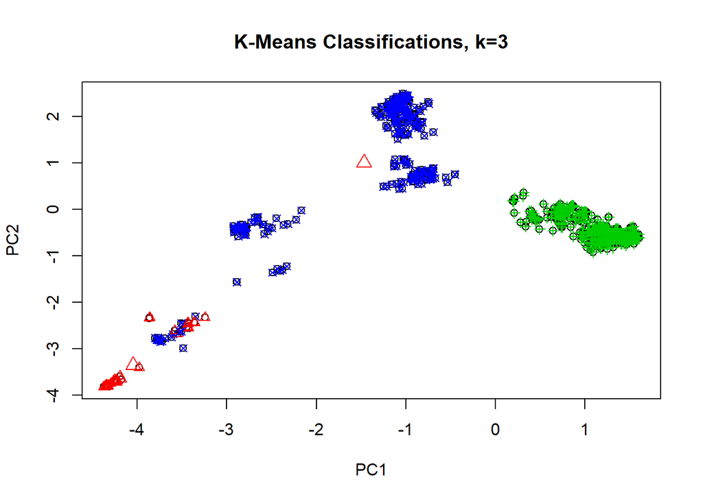

```r
kunique <- kmeans(pca.frame,34) # Because I know how many groups there are and I want to see what cheating will do for us
plot(pca.frame, main="K-Means Classifications, k=3")
points(pca.frame,pch=k3$cluster+1, col=k3$cluster+1)
points(k3$centers, col=2:3, pch=2:3, cex=1.5)
```

```r
table(k3$cluster,Mt$Group)
```

```
##
##       A   B   C CNSS   D   F   G   H   I   J   K  L0  L1 L1b  L2  L3 L3e
##   1   0   0   0    0   0   0   0   0   0   0   0   0  12  27   0   0   0
##   2  87  87   0    0   0  29   0 177   6  35  24   0   0   0   0   0   0
##   3   0   0  33    0  88   0  20   0   0   0   0  23   0   0  63  45  51
##
##     L3h  L5  Lx  Ly   M   N   O Position_site   Q   R RSRS   S   T   U   V
##   1   0   0   0   0   0   0   0             0   0   0    0   0   0   0   0
##   2   0   0   0   0   0  24   6             0   4   6    0   1  36  83  13
##   3   6   9   7   1  52   0   0             0   0   0    0   0   0   0   0
##
##       W   X
##   1   0   0
##   2  12   7
##   3   0   0
```

```r
adjustedRandIndex(k3$cluster,Mt$Group)
```

```
## [1] 0.1430189
```

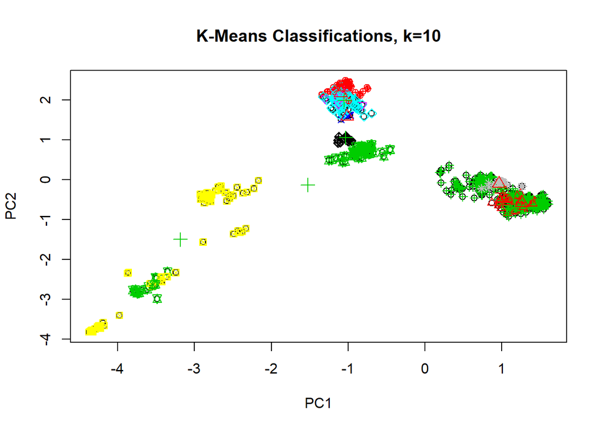

```r
plot(pca.frame, main="K-Means Classifications, k=10")
points(pca.frame,pch=k10$cluster+1, col=k10$cluster+1)
points(k10$centers, col=2:3, pch=2:3, cex=1.5)
```

```r
table(k10$cluster,Mt$Group)
```

```
##
##        A   B   C CNSS   D   F   G   H   I   J   K  L0  L1 L1b  L2  L3 L3e
##   1    0   0   0    0   0   0   0   0   0   0  24   0   0   0   0   0   0
##   2   87  87   0    0   0  29   0 177   6   0   0   0   0   0   0   0   0
##   3    0   0   0    0   0   0   0   0   0   0   0   0   0   0   0   0   0
##   4    0   0  33    0   0   0  20   0   0   0   0   0   0   0   0   0   0
##   5    0   0   0    0  21   0   0   0   0   0   0   0   0   0   0   0   0
##   6    0   0   0    0   0   0   0   0   0   0   0   0  12  27  63   0   0
##   7    0   0   0    0   0   0   0   0   0  35   0   0   0   0   0   0   0
##   8    0   0   0    0   0   0   0   0   0   0   0   0   0   0   0  37   0
##   9    0   0   0    0  67   0   0   0   0   0   0   0   0   0   0   0   0
##   10   0   0   0    0   0   0   0   0   0   0   0  23   0   0   0   8  51
##
##      L3h  L5  Lx  Ly   M   N   O Position_site   Q   R RSRS   S   T   U
##   1    0   0   0   0   0   0   0             0   0   0    0   0   0  83
```

[output cut: 21 more lines]

```r
adjustedRandIndex(k10$cluster,Mt$Group)
```

```
## [1] 0.3316396
```

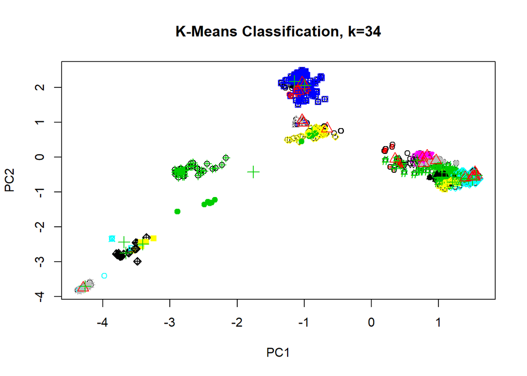

```r
plot(pca.frame,main="K-Means Classification, k=34")
points(pca.frame,pch=kunique$cluster+1, col=kunique$cluster+1)
points(kunique$centers, col=2:3, pch=2:3, cex=1.5)
```

```r
table(kunique$cluster,Mt$Group)
```

```
##
##       A  B  C CNSS  D  F  G  H  I  J  K L0 L1 L1b L2 L3 L3e L3h L5 Lx Ly
##   1   0  0  0    0  0  0  0  7  0  0  0  0  0   0  0  0   0   0  0  0  0
##   2   0  0  0    0  0  0  0  0  0  0  0  0  0   0 63  0   0   0  0  0  0
##   3   0  0  0    0  0  0  0  0  0  0  0  0  0   0  0  0   0   0  0  0  0
##   4   0  0  0    0  0  0  0 93  0  0  0  0  0   0  0  0   0   0  0  0  0
##   5  62  0  0    0  0  0  0  0  0  0  0  0  0   0  0  0   0   0  0  0  0
##   6   0  0  0    0  0  0  0  0  0  0  0  0  0   0  0  0   0   0  0  0  0
##   7   0  0  0    0  0  0  0  0  0  0  0  0  0  22  0  0   0   0  0  0  0
##   8   0  0  0    0  0  0  0  0  0  0  0 23  0   0  0  0   0   0  0  0  0
##   9   0  0  0    0  0  0 16  0  0  0  0  0  0   0  0  0   0   0  0  0  0
##   10  0  0  0    0  0  0  0  0  0  0  0  0  0   0  0  0   0   0  0  0  0
##   11  0  0  0    0 88  0  4  0  0  0  0  0  0   0  0  0   0   0  0  0  0
##   12  0  0  0    0  0  0  0  0  0  0  0  0  4   0  0  0   0   0  0  0  0
##   13 25  0  0    0  0  0  0  0  0  0  0  0  0   0  0  0   0   0  0  0  0
```

[output cut: 57 more lines]

```r
adjustedRandIndex(kunique$cluster,Mt$Group)
```

```
## [1] 0.5759006
```

As we would expect, our accuracy improves as the number of predicted clusters increases. There may be a more nuanced view of this data, but from the original view of my 218 dimensional data (pressed onto a 2D graph), the groups do appear to cluster in roughly three groups. Perhaps, given a better computer and allowing it to run for a week, we would get these models to see the different 34 groups that actually exist in the model. We still have hierarchical clustering to try though.

```r
e <- dist(pca.frame,method="euclidian")
m <- dist(pca.frame, method="maximum")
man <- dist(pca.frame, method="manhattan")
b <- dist(pca.frame, method="binary")
hclust.s.e <- hclust(e, method="single")
hclust.s.m <- hclust(m, method="single")
hclust.s.man <- hclust(man, method="single")
hclust.s.b <- hclust(b, method="single")
hclust.c.b <- hclust(b, method="complete")
hclust.c.man <- hclust(man, method="complete")
hclust.c.m <- hclust(m, method="complete")
hclust.c.e <- hclust(e, method="complete")
hclust.a.e <- hclust(e, method="average")
hclust.a.m <- hclust(m, method="average")
hclust.a.man <- hclust(man, method="average")
hclust.a.b <- hclust(b, method="average")
hclust.w.b <- hclust(b, method="ward.D2")
hclust.w.m <- hclust(m, method="ward.D2")
hclust.w.man <- hclust(man, method="ward.D2")
hclust.w.e <- hclust(e, method="ward.D2")
```

I ran a whole boat load of models to see if we can’t get a good predictive model. I spared you having to go through lines of code, I only reported the best model. I cut the trees at our previously found 3, 10, and 34 groups that NbClust and Mclust specified.

```r
adjustedRandIndex(Mt$Group,cutree(hclust.w.e,10))
```

```
## [1] 0.5816427
```

```r
adjustedRandIndex(Mt$Group,cutree(hclust.w.e,34))
```

```
## [1] 0.8057748
```

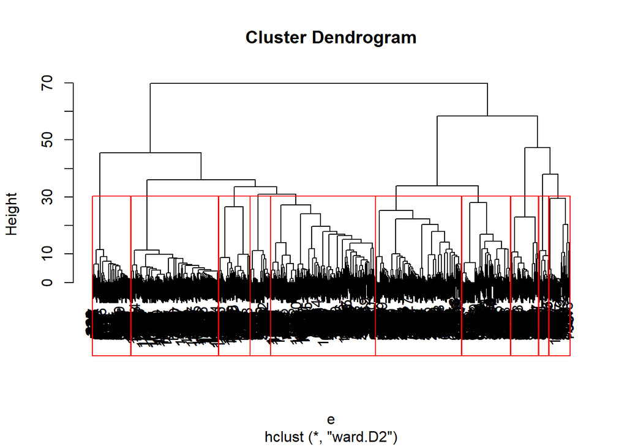

```r
plot(hclust.w.e)
rect.hclust(hclust.w.e,k=10,border = "red")
```

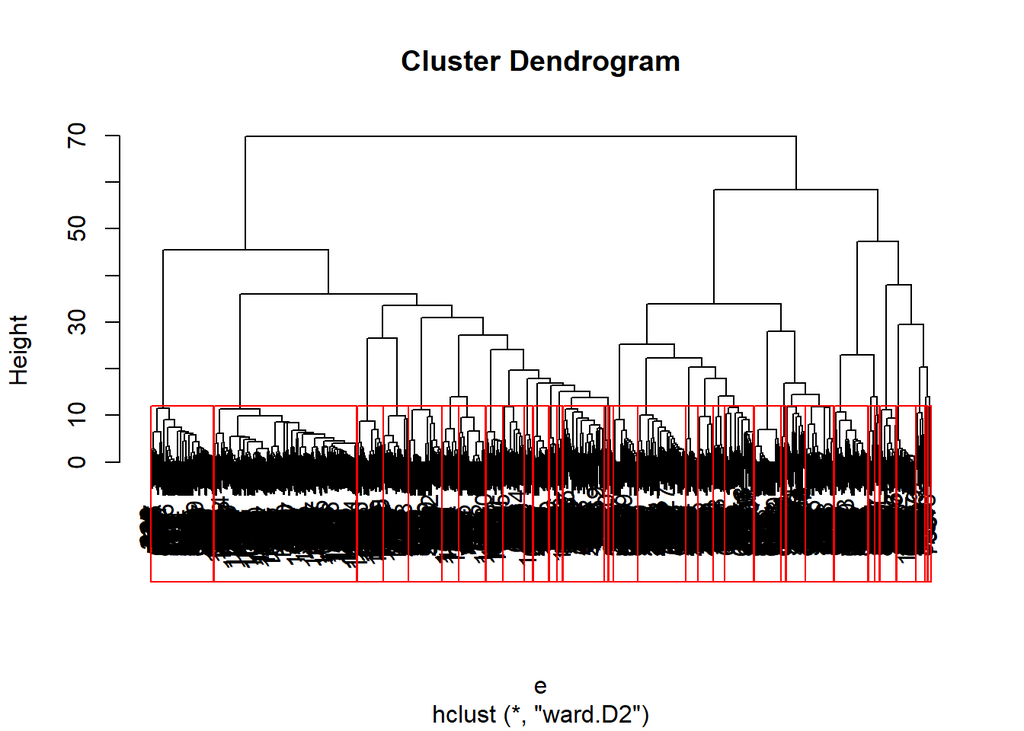

```r
plot(hclust.w.e)
rect.hclust(hclust.w.e,k=34,border = "red")
```

Once again as the number of groupings increased, so did the accuracy of our models. It appears to improve our models, we would want to look into how to get these clustering techniques to find more groupings within the PCA data.

### Association

I was curious to see what rules would go together. It won’t be as interesting as say the happiness dataset, since the variables are unremarkably named “X###”. But this dataset, already given to us in a sparse 0,1 dataset is too good to pass up the opportunity to flex these assocation skills. The following is a brief digression into how these SNPs relate to one another through conditional probability.

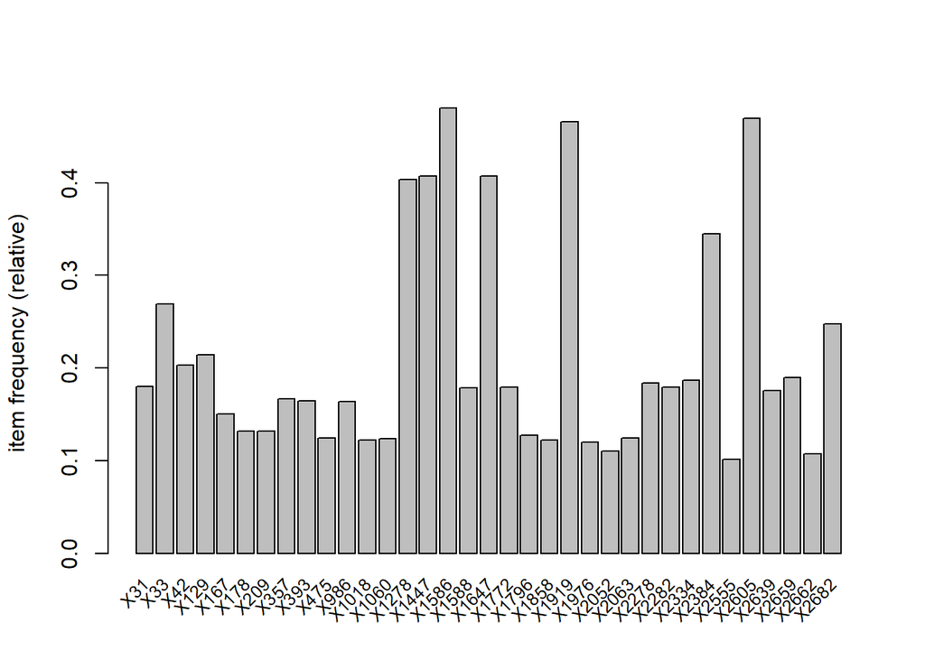

```r
assoc <- as(Mt.m,"transactions")
itemFrequencyPlot(assoc[, itemFrequency(assoc) > 0.1], cex.names = 0.8)
```

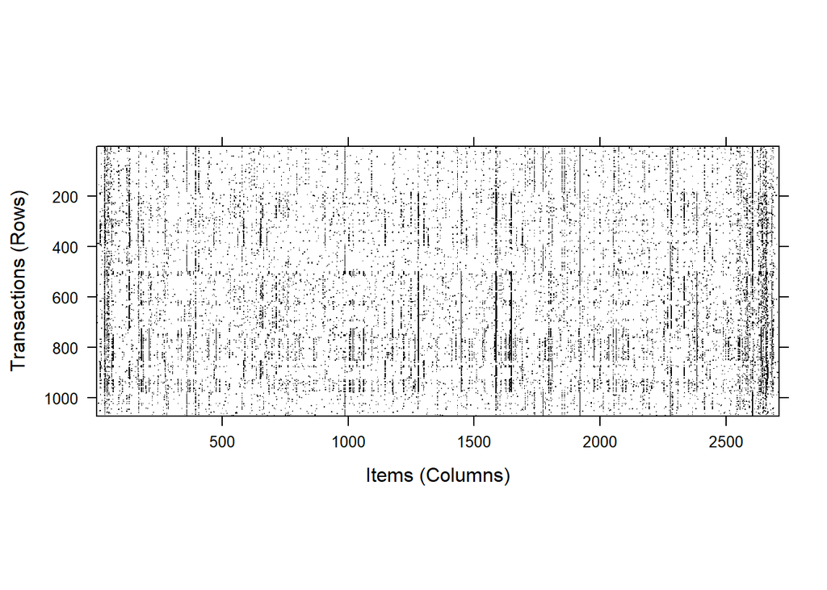

```r
image(assoc, method = NULL, measure = "support", shading = "lift", interactive = FALSE, data = NULL, control = NULL, engine = "default")
```

```r
rules <- apriori(assoc, parameter = list(support = 0.1, confidence = 0.6))
```

```
## Apriori
##
## Parameter specification:
##  confidence minval smax arem  aval originalSupport maxtime support minlen
##         0.6    0.1    1 none FALSE            TRUE       5     0.1      1
##  maxlen target   ext
##      10  rules FALSE
##
## Algorithmic control:
##  filter tree heap memopt load sort verbose
##     0.1 TRUE TRUE  FALSE TRUE    2    TRUE
##
## Absolute minimum support count: 107
##
## set item appearances ...[0 item(s)] done [0.00s].
## set transactions ...[2496 item(s), 1074 transaction(s)] done [0.01s].
## sorting and recoding items ... [35 item(s)] done [0.00s].
## creating transaction tree ... done [0.00s].
## checking subsets of size 1 2 3 4 5 6 7 8 9 10
```

```
##  done [0.00s].
## writing ... [16599 rule(s)] done [0.00s].
## creating S4 object  ... done [0.01s].
```

```r
rules.sort <- sort(rules, by="confidence")
inspect(rules.sort[1:3,])
```

```
##     lhs       rhs     support   confidence lift     count
## [1] {X986} => {X357}  0.1638734 1          6.000000 176
## [2] {X986} => {X2278} 0.1638734 1          5.424242 176
## [3] {X986} => {X1919} 0.1638734 1          2.148000 176
```

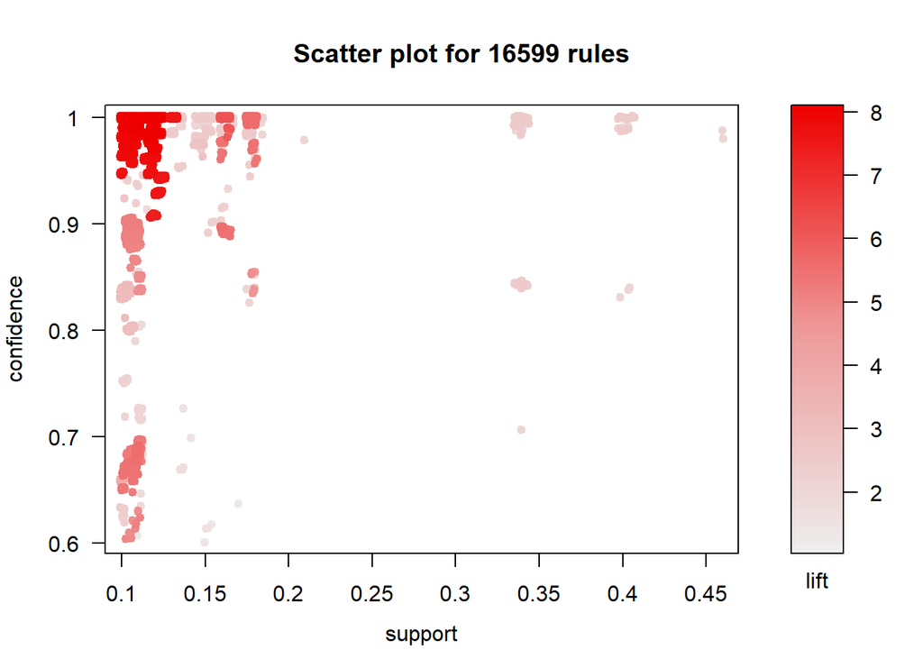

```r
plot(rules)
```